[figure not shown]

# Tarea 1

## Profesor: Jaime Vázquez Alamilla

## Ayudante: Alejandro Cuevas

Casandra Sofía Pejcovich

Carlos Luna Hernández

Aldo Enrique Chong Valentín

Luis Fernando Apáez Álvarez

## Índice

Pregunta 1

Inciso a)

Inciso b)

Inciso c)

Inciso d)

Inciso e)

Inciso f)

Inciso g)

Pregunta 2

Pregunta 3

## Pregunta 1: Trabajar con el dataset **planes** de la librería **nycflights13**:

Comenzaremos por llamar a las librerías necesarias:

```r
library(dplyr)
library(nycflights13)
library(ggplot2)
```

y revisamos que los paquetes estén en nuestra lista de búsqueda actual:

```r
search()
```

```
##  [1] ".GlobalEnv"           "package:ggplot2"      "package:nycflights13"
##  [4] "package:dplyr"        "package:stats"        "package:graphics"
##  [7] "package:grDevices"    "package:utils"        "package:datasets"
## [10] "package:methods"      "Autoloads"            "package:base"
```

Ahora bien, pasemos a resolver cada uno de los incisos de este primer ejercicio:

### Inciso *a)*

El número de columnas que tiene la tabla está dado por el número.

```r
col_planes <- ncol(planes)
print(paste("Número de columnas:", col_planes))
```

```
## [1] "Número de columnas: 9"
```

Luego, para conocer el número de registro multiplicamos el número de filas por el número de columnas.

```r
# Conocemos primero el número de filas
row_planes <- nrow(planes)

# Calculamos
num_registros <- col_planes * row_planes
print(paste("El número de registros es de:", num_registros))
```

```
## [1] "El número de registros es de: 29898"
```

### Inciso b)

Asignamos a cada vector la descripción de la variable en cada columna:

```r
col_1 <- "el número de cola (tail number)"
col_2 <- "el año de fabricaciÃ³n (year manufactured)"
col_3 <- "el tipo de avión (type of plane)"
col_4 <- "el fabricante (manufacturer)"
col_5 <- "el modelo (model)"
col_6 <- "el número de motores (number of engines)"
col_7 <- "el número de asientos (number of seats)"
col_8 <- "la velocidad crucero promedio en millas por hora (average crusing speed in mph)"
col_9 <- "el tipo de motor (type of engine)"
```

Concatenamos por fila los vectores anteriores en una matriz que podamos mandar llamar,

```r
matriz_desc <- rbind(col_1,col_2,col_3,col_4,col_5,col_6,col_7,col_8,col_9)
matriz_desc
```

```
##       [,1]
## col_1 "el número de cola (tail number)"
## col_2 "el año de fabricaciÃ³n (year manufactured)"
## col_3 "el tipo de avión (type of plane)"
## col_4 "el fabricante (manufacturer)"
## col_5 "el modelo (model)"
## col_6 "el número de motores (number of engines)"
## col_7 "el número de asientos (number of seats)"
## col_8 "la velocidad crucero promedio en millas por hora (average crusing speed in mph)"
## col_9 "el tipo de motor (type of engine)"
```

y creamos una lista con los tipos de datos:

```r
tipodato_col <- lapply(planes, class)
tipodato_col
```

```
## $tailnum
## [1] "character"
##
## $year
## [1] "integer"
##
## $type
## [1] "character"
##
## $manufacturer
## [1] "character"
##
## $model
## [1] "character"
##
## $engines
## [1] "integer"
##
## $seats
## [1] "integer"
##
## $speed
## [1] "integer"
##
## $engine
## [1] "character"
```

Después, creamos una función que concatene texto y los datos: número de columna, nombre de la columna del dataframe planes, descripción de los valores que almacena y tipo de dato que contiene; para cada una de las 9 columnas:

```r
fun1 <- function() {
  for (i in 1:col_planes) {
    print(paste("Col",i,":","'",colnames(planes)[i],"'","representa",matriz_desc[i],"y es
                de tipo",tipodato_col[i]))
  }
}

fun1()
```

```
## [1] "Col 1 : ' tailnum ' representa el número de cola (tail number) y es \n                de tipo character"
## [1] "Col 2 : ' year ' representa el año de fabricaciÃ³n (year manufactured) y es \n                de tipo integer"
## [1] "Col 3 : ' type ' representa el tipo de avión (type of plane) y es \n                de tipo character"
## [1] "Col 4 : ' manufacturer ' representa el fabricante (manufacturer) y es \n                de tipo character"
## [1] "Col 5 : ' model ' representa el modelo (model) y es \n                de tipo character"
## [1] "Col 6 : ' engines ' representa el número de motores (number of engines) y es \n                de tipo integer"
## [1] "Col 7 : ' seats ' representa el número de asientos (number of seats) y es \n                de tipo integer"
## [1] "Col 8 : ' speed ' representa la velocidad crucero promedio en millas por hora (average crusing speed in mph) y es \n                de tipo integer"
## [1] "Col 9 : ' engine ' representa el tipo de motor (type of engine) y es \n                de tipo character"
```

### Inciso c)

Comenzamos creando un factor de la columna `manufacturer` del dataframe `planes`

```r
planes_factor <- factor(planes$manufacturer)
```

Gracias a la estructura de los factores, podemos hallar los registros distintos entre el total de filas con:

```r
levels(planes_factor)
```

```
##  [1] "AGUSTA SPA"                    "AIRBUS"
##  [3] "AIRBUS INDUSTRIE"              "AMERICAN AIRCRAFT INC"
##  [5] "AVIAT AIRCRAFT INC"            "AVIONS MARCEL DASSAULT"
##  [7] "BARKER JACK L"                 "BEECH"
##  [9] "BELL"                          "BOEING"
## [11] "BOMBARDIER INC"                "CANADAIR"
## [13] "CANADAIR LTD"                  "CESSNA"
## [15] "CIRRUS DESIGN CORP"            "DEHAVILLAND"
## [17] "DOUGLAS"                       "EMBRAER"
## [19] "FRIEDEMANN JON"                "GULFSTREAM AEROSPACE"
## [21] "HURLEY JAMES LARRY"            "JOHN G HESS"
## [23] "KILDALL GARY"                  "LAMBERT RICHARD"
## [25] "LEARJET INC"                   "LEBLANC GLENN T"
## [27] "MARZ BARRY"                    "MCDONNELL DOUGLAS"
## [29] "MCDONNELL DOUGLAS AIRCRAFT CO" "MCDONNELL DOUGLAS CORPORATION"
## [31] "PAIR MIKE E"                   "PIPER"
## [33] "ROBINSON HELICOPTER CO"        "SIKORSKY"
## [35] "STEWART MACO"
```

Luego, comprobamos que lo anterior sea un vector de longitud `[1:35]`

```r
str(levels(planes_factor))
```

```
##  chr [1:35] "AGUSTA SPA" "AIRBUS" "AIRBUS INDUSTRIE" ...
```

De nuevo, aprovechando la creación del vector, usamos función `summary` para contabilizar el número de registros por nivel.

```r
summary(planes_factor)
```

```
##                    AGUSTA SPA                        AIRBUS
##                             1                           336
##              AIRBUS INDUSTRIE         AMERICAN AIRCRAFT INC
##                           400                             2
##            AVIAT AIRCRAFT INC        AVIONS MARCEL DASSAULT
##                             1                             1
##                 BARKER JACK L                         BEECH
##                             1                             2
##                          BELL                        BOEING
##                             2                          1630
##                BOMBARDIER INC                      CANADAIR
##                           368                             9
##                  CANADAIR LTD                        CESSNA
##                             1                             9
##            CIRRUS DESIGN CORP                   DEHAVILLAND
##                             1                             1
##                       DOUGLAS                       EMBRAER
##                             1                           299
##                FRIEDEMANN JON          GULFSTREAM AEROSPACE
##                             1                             2
##            HURLEY JAMES LARRY                   JOHN G HESS
##                             1                             1
##                  KILDALL GARY               LAMBERT RICHARD
##                             1                             1
##                   LEARJET INC               LEBLANC GLENN T
##                             1                             1
##                    MARZ BARRY             MCDONNELL DOUGLAS
##                             1                           120
## MCDONNELL DOUGLAS AIRCRAFT CO MCDONNELL DOUGLAS CORPORATION
##                           103                            14
##                   PAIR MIKE E                         PIPER
##                             1                             5
##        ROBINSON HELICOPTER CO                      SIKORSKY
##                             1                             1
##                  STEWART MACO
##                             2
```

Comprobamos que lo anterior también es un vector de long `[1:35]`

```r
str(summary(planes_factor))
```

```
##  Named int [1:35] 1 336 400 2 1 1 1 2 2 1630 ...
##  - attr(*, "names")= chr [1:35] "AGUSTA SPA" "AIRBUS" "AIRBUS INDUSTRIE" "AMERICAN AIRCRAFT INC" ...
```

Creamos un dataframe (tibble) que se alimente de los niveles y del número de registros por cada uno de estos:

```r
planes_tibble <- tibble(m = levels(planes_factor), r = summary(planes_factor))
planes_tibble
```

```
## # A tibble: 35 x 2
##    m                          r
##    <chr>                  <int>
##  1 AGUSTA SPA                 1
##  2 AIRBUS                   336
##  3 AIRBUS INDUSTRIE         400
##  4 AMERICAN AIRCRAFT INC      2
##  5 AVIAT AIRCRAFT INC         1
##  6 AVIONS MARCEL DASSAULT     1
##  7 BARKER JACK L              1
##  8 BEECH                      2
##  9 BELL                       2
## 10 BOEING                  1630
## # ... with 25 more rows
```

Guardamos el tibble organizado de manera descendiente sobre los registros, en una nueva variable.

```r
planes_desc <- arrange(planes_tibble, desc(r))
planes_desc
```

```
## # A tibble: 35 x 2
##    m                                 r
##    <chr>                         <int>
##  1 BOEING                         1630
##  2 AIRBUS INDUSTRIE                400
##  3 BOMBARDIER INC                  368
##  4 AIRBUS                          336
##  5 EMBRAER                         299
##  6 MCDONNELL DOUGLAS               120
##  7 MCDONNELL DOUGLAS AIRCRAFT CO   103
##  8 MCDONNELL DOUGLAS CORPORATION    14
##  9 CANADAIR                          9
## 10 CESSNA                            9
## # ... with 25 more rows
```

Creamos un nuevo tibble que sólo tome las primeras 3 filas del tibble anterior en orden descendiente.

```r
gg_tibble <- tibble(Fa = planes_desc$m[c(1,2,3)], Registros = planes_desc$r[c(1,2,3)])
```

Asignamos a un vector el “orden descendiente” por medio de la función `levels` aplicada sobre un factor.

```r
Fabricantes <- factor(gg_tibble$Fa, level =  planes_desc$m[c(1,2,3)])

# Creamos el vector que almacena los colores para la grafica

colors <- c("#845EC2", "#D65DB1","#FF9671")
```

Graficamos un barplot con los tres fabricantes con más registros en la tabla, en orden descendiente.

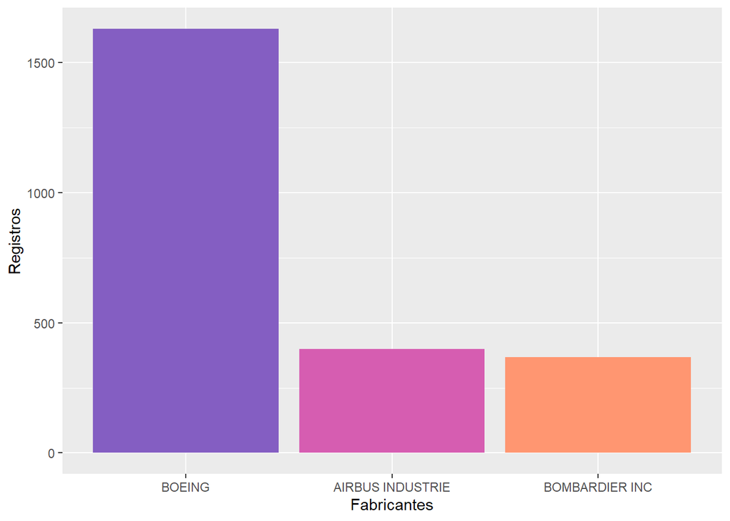

```r
ggplot( data = gg_tibble, mapping = aes(x= Fabricantes, y = Registros)) +
  geom_bar(stat = "identity", fill = colors)
```

### Inciso d)

Comenzamos por filtrar los datos por año hasta 1983.

```r
# Filtro:
filter1 <- planes %>%
  filter(year <= 1983)

# Imprimimos nuestro nuevo dataset
filter1
```

```
## # A tibble: 30 x 9
##    tailnum  year type          manufacturer model   engines seats speed engine
##    <chr>   <int> <chr>         <chr>        <chr>     <int> <int> <int> <chr>
##  1 N14629   1965 Fixed wing m~ BOEING       737-524       2   149    NA Turbo-f~
##  2 N201AA   1959 Fixed wing s~ CESSNA       150           1     2    90 Recipro~
##  3 N202AA   1980 Fixed wing m~ CESSNA       421C          2     8    90 Recipro~
##  4 N350AA   1980 Fixed wing m~ PIPER        PA-31-~       2     8   162 Recipro~
##  5 N364AA   1973 Fixed wing m~ CESSNA       310Q          2     6   167 Recipro~
##  6 N376AA   1978 Fixed wing s~ PIPER        PA-32R~       1     7    NA Recipro~
##  7 N378AA   1963 Fixed wing s~ CESSNA       172E          1     4   105 Recipro~
##  8 N381AA   1956 Fixed wing m~ DOUGLAS      DC-7BF        4   102   232 Recipro~
##  9 N383AA   1972 Fixed wing m~ BEECH        E-90          2    10    NA Turbo-p~
## 10 N425AA   1968 Fixed wing s~ PIPER        PA-28-~       1     4   107 Recipro~
## # ... with 20 more rows
```

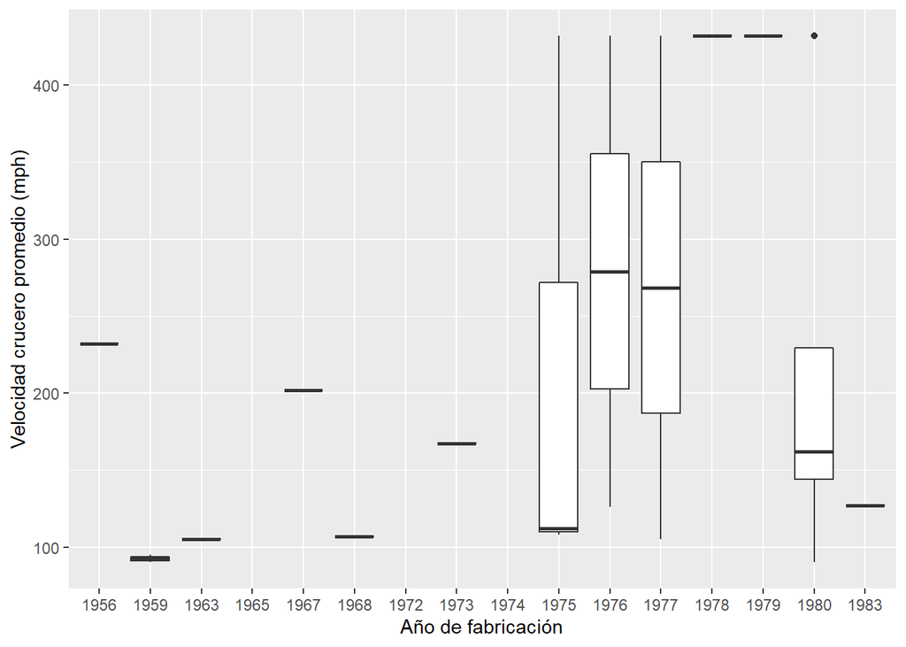

```r
ggplot(data = filter1, mapping = aes (x = factor(year), y = speed)) +
  geom_boxplot() +labs(x= "Año de fabricación", y = "Velocidad crucero promedio (mph)")
```

```r
df1 <- data.frame(year = filter1$year, speed =filter1$speed)
df1
```

```
##    year speed
## 1  1965    NA
## 2  1959    90
## 3  1980    90
## 4  1980   162
## 5  1973   167
## 6  1978    NA
## 7  1963   105
## 8  1956   232
## 9  1972    NA
## 10 1968   107
## 11 1975   112
## 12 1979    NA
## 13 1983   127
## 14 1980   162
```

[output cut: 16 more lines]

Mandamos llamar sólo a la columna que corresponde a los años, observamos que hay años que aparecen más de una vez. Además, creamos un factor a partir del vector df1 (años) y aplicamos la función `levels()` para que regrese los años únicos.

```r
# mandamos a llamar a la columna correspondiente de los años
df1$year
```

```
##  [1] 1965 1959 1980 1980 1973 1978 1963 1956 1972 1968 1975 1979 1983 1980 1976
## [16] 1959 1963 1979 1967 1975 1975 1976 1977 1976 1977 1978 1979 1979 1980 1974
```

```r
# creamos un factor y aplicamos la función levels
niv <- levels(factor(df1$year))
niv
```

```
##  [1] "1956" "1959" "1963" "1965" "1967" "1968" "1972" "1973" "1974" "1975"
## [11] "1976" "1977" "1978" "1979" "1980" "1983"
```

Como la función `levels()` nos regresa un vector con entradas de tipo `<char>`. Usamos `lapply` para aplicar a cada entrada del vector una función que convierta los `<char>` en `<int>`. Notemos que `lapply()` regresa una LISTA con entradas tipo `<int>`.

```r
niv1 <- lapply(niv, as.integer)
niv1
```

```
## [[1]]
## [1] 1956
##
## [[2]]
## [1] 1959
##
## [[3]]
## [1] 1963
##
## [[4]]
## [1] 1965
##
## [[5]]
## [1] 1967
##
## [[6]]
## [1] 1968
##
## [[7]]
## [1] 1972
##
## [[8]]
## [1] 1973
##
## [[9]]
## [1] 1974
##
## [[10]]
## [1] 1975
##
## [[11]]
## [1] 1976
##
## [[12]]
## [1] 1977
##
## [[13]]
## [1] 1978
##
## [[14]]
## [1] 1979
##
## [[15]]
## [1] 1980
##
## [[16]]
## [1] 1983
```

Luego:

- Creamos un dataframe vacio `df3 <- data.frame()`.
- Creamos un ciclo `for` para cada año en la lista de años únicos `niv1`.
- creamos un nuevo dataframe que filtre el dataframe acotado `df1` y solo regrese las velocidades asociadas a ese año particular.
- Estando en ese nuevo dataframe acotado y filtrado por años, calculamos la varianza de los valores de velocidad y la guardamos en la variable `i`. Le pediremos que elimine del cálculo los valores `NA`.
- Creamos un vector que incluya el año por el que estamos filtrando, la mediana de las velocidades y la varianza de ese año almacenada en `i` (para esta iteración).
- Pegamos por renglón a ese vector al dataframe vacio `df3` # Reescribimos sobre `df3` para que guarde los registros de cada iteración.

Lo anterior se traduce en código como:

```r
# Dataframe vacío
df3 <- data.frame()

# ciclo form
for(fecha in niv1){
  filtro <- df1 %>%
    filter(year == fecha)
  i <- var(filtro$speed, na.rm = TRUE)
  df3 <- rbind(df3,c(fecha,median(filtro$speed, na.rm = TRUE),i))
}

# Mandamos llamar a df3 para verificar los registros
df3
```

```
##    X1956  X232 NA_real_.
## 1   1956 232.0        NA
## 2   1959  92.5     12.50
## 3   1963 105.0        NA
## 4   1965    NA        NA
## 5   1967 202.0        NA
## 6   1968 107.0        NA
## 7   1972    NA        NA
## 8   1973 167.0        NA
## 9   1974    NA        NA
## 10  1975 112.0  34565.33
## 11  1976 279.0  46818.00
## 12  1977 268.5  53464.50
## 13  1978 432.0        NA
## 14  1979 432.0      0.00
## 15  1980 162.0  22761.00
## 16  1983 127.0        NA
```

Continuando,

```r
# Renombramos las columnas de df3 para que reflejen lo que almacenan
colnames(df3) <- c("año","mediana","varianza")

# Ordenamos sobre la varianza de forma desc a df3 y guardamos en un nuevo
# dataframe df4
df4 <- df3[order(df3[,3], decreasing = TRUE),]

# Almacenamos en dataframe df5 sólo los primeros 4 registros con mayor varianza
df5 <- df4[1:4,]

# Ordenamos sobre mediana de forma desc a df5 y guardamos en dataframe df6
df6 <- df5[order(df5[,2], decreasing = TRUE),]
```

Finalmente, guardamos en una nueva variable solo los años ordenados sobre la mediana de forma descendiente.

```r
inciso_d <- df6[,1]

# Veamos el resultado final buscado en este inciso

print("De las 4 cajas con más registros, los años de mayor mediana en la velocidad, en orden descendiente son:")
```

```
## [1] "De las 4 cajas con más registros, los años de mayor mediana en la velocidad, en orden descendiente son:"
```

```r
inciso_d
```

```
## [1] 1976 1977 1980 1975
```

### Inciso e)

Buscamos el máximo valor de la columna varianza en el dataframe `df6` :

```r
max(df6[,3])
```

```
## [1] 53464.5
```

Guardamos en un dataframe `df7` un filtro de `df6` tal que busque el máximo valor de la varianza en la tercera columna de `df6`y guardamos sólo la(s) coincidencia(s).

```r
df7 <- df6 %>%
filter(df6[,3]==max(df6[,3]))
df7
```

```
##    año mediana varianza
## 1 1977   268.5  53464.5
```

Teniendo así como resultado final:

```r
print(paste("El año con mayor varianza es",df7[1,1],"."))
```

```
## [1] "El año con mayor varianza es 1977 ."
```

### Inciso f)

Filtramos los datos deseados:

```r
Aviones_BOEING<- planes %>%
  filter(manufacturer == "BOEING")
glimpse(Aviones_BOEING)
```

```
## Rows: 1,630
## Columns: 9
## $ tailnum      <chr> "N11206", "N1200K", "N1201P", "N12109", "N12114", "N12...
## $ year         <int> 2000, 1998, 1998, 1994, 1995, 1996, 1998, 1987, 1998, ...
## $ type         <chr> "Fixed wing multi engine", "Fixed wing multi engine", ...
## $ manufacturer <chr> "BOEING", "BOEING", "BOEING", "BOEING", "BOEING", "BOE...
## $ model        <chr> "737-824", "767-332", "767-332", "757-224", "757-224",...
## $ engines      <int> 2, 2, 2, 2, 2, 2, 2, 2, 2, 2, 2, 2, 2, 2, 2, 2, 2, 2, ...
## $ seats        <int> 149, 330, 330, 178, 178, 178, 178, 330, 149, 149, 149,...
## $ speed        <int> NA, NA, NA, NA, NA, NA, NA, NA, NA, NA, NA, NA, NA, NA...
## $ engine       <chr> "Turbo-fan", "Turbo-fan", "Turbo-fan", "Turbo-jet", "T...
```

Ahora, procederemos a usar la función `stem()` para realizar el diagrama de tallo y hojas.

```r
Asientos <-Aviones_BOEING$seats
inciso_f <- stem(Asientos)
```

```
##
##   The decimal point is 1 digit(s) to the right of the |
##
##   10 | 00000000000000000000000000000000000000000000000000000000000000000000+8
##   12 | 8
##   14 | 00000000000000000000000000000000000000000000000000000000000000000000+793
##   16 | 88888888888888888888888888888888888888888888888888888888888888888888+203
##   18 | 99999999999999999999999999999999999999999999999999999999999999999999+80
##   20 |
##   22 | 2222222222222
##   24 | 5555555555555555
##   26 | 000095555555555555555555555555
##   28 | 0000002222222222222222
##   30 | 00000000000000000
##   32 | 00000000000000000000000000000000000000000000000000000000000000000000+34
##   34 |
##   36 |
##   38 |
##   40 | 000000000000
##   42 |
##   44 | 0
```

### Inciso g)

*i)* Procedemos a sacar el Rango muestral o Rango.

```r
max(Aviones_BOEING$seats)-min(Aviones_BOEING$seats)
```

```
## [1] 350
```

*ii)* y *iii)* Para ello,

```r
# Media
esp <- mean(Aviones_BOEING$seats)

#Continuamos con la  varianza y la desviacion estandar
varian <-var(Aviones_BOEING$seats)
desvi_estan <-sd(Aviones_BOEING$seats)
```

de donde,

```r
paste("Media:", esp, "Varianza:",varian,"Desviación est:",desvi_estan)
```

```
## [1] "Media: 175.18773006135 Varianza: 3536.53932142494 Desviación est: 59.4688096519927"
```

*iv)* Procedemos con los cuartiles.

```r
# Cuartiles

quantile(Aviones_BOEING$seats, 0.25)
```

```
## 25%
## 140
```

```r
quantile(Aviones_BOEING$seats, 0.75)
```

```
## 75%
## 178
```

El rango intercuantil:

```r
IQR(Aviones_BOEING$seats)
```

```
## [1] 38
```

o, alternativamente:

```r
quantile(Aviones_BOEING$seats, 0.75)-quantile(Aviones_BOEING$seats, 0.25)
```

```
## 75%
##  38
```

*v)* El sesgo y su interpretación. Para ello debemos cargar el paquete `e1071` y una vez instalado procedemos.

```r
library(e1071)
```

Comenzamos con el sesgo:

```r
sesgo <- skewness(Aviones_BOEING$seats)
```

y para la interpretación correspondiente creamos la siguiente función:

```r
fun_sesgo <- function(x){
  if(x>0){
  var <- "existen muchos valores en la muestra que son mayores que la media, i.e.,la distribución está concentrada a la izquierda"
  }
  else if(x<0){
  var <- "existen muchos valores en la muestra que son menores que la media, i.e.,la distribución está concentrada a la derecha"
  }
  print(paste("El sesgo es:",x))
  print(paste("Implica que",var))
}

# de modo que
fun_sesgo(sesgo)
```

```
## [1] "El sesgo es: 1.81427613383934"
## [1] "Implica que existen muchos valores en la muestra que son mayores que la media, i.e.,la distribución está concentrada a la izquierda"
```

*vi)* La curtosis y su interpretacion. De manera análoga al inciso anterior, escribimos:

```r
  kurtosis <-  kurtosis(Aviones_BOEING$seats)

  fun_kurt <- function(x){
    if(x>0){
      var <- "Es leptocúrtica, i.e., presenta decaimiento rápido con colas ligeras."
    }
    else if(x==0){
      var <- "Es mesocúrtica, i.e., es la curva normal."
    }
    else{
      var <- "Es platicúrtica, i.e., tiene decaimiento rápido y colas amplias."
    }
    print(paste("La kurtosis es:",x))
    print(var)
  }

# Para finalmente obtener
fun_kurt(kurtosis)
```

```
## [1] "La kurtosis es: 2.74608521404107"
## [1] "Es leptocúrtica, i.e., presenta decaimiento rápido con colas ligeras."
```

## Pregunta 2: Escriba una función que se llame *truncar* como se especifica en la tarea.

*Solución:*

- Utilizaremos la función predefinida `as.integer()` para extraer la parte entera de un número. Así, al efectuar la diferencia entre el número y su parte entera obtendremos los decimales de dicho número, por ejemplo $2.5421 - 2 =0.5421$. Luego, de acuerdo al número de decimales que queramos mostrar, digamos $k$, entonces multiplicaremos dicha diferencia por $10^k$. Por ejemplo, supongamos que queremos mostrar dos decimales de $2.5421$ (es decir, mostrar el número $2.54$), por lo que consideraremos $0.5421 \cdot 10^2=54.21$ (es decir `x <- (2.5421-as.integer(2.5421)) * 10 ** 2`) y a este resultado nuevamente le obtendremos su parte entera con `as.integer(x)`. Lo anterior nos arrojará $54$ de modo que, para obtener el resultado buscado, bastará con efectuar $2 + \frac{54}{100}=2+\frac{54}{10^2}=2.54$, es decir `as.integer(2.5421) + as.integer(x / 10 ** 2)`.
- Para el caso en que el número decimal tenga como parte entera el cero, por ejemplo el $0.1416$, bastará con multiplicar ese número por $10^k$, donde $k$ es el número de decimales que queremos mostrar, digamos $k=3$. Entonces tendremos $0.1416 \cdot 10^3=141.6$ al cual le obtendremos su parte entera y después dividiremos entre $10^3$ para tener que $\frac{141}{10^3}=0.141$.

Ahora, en código tendríamos que

```r
# Definimos la función truncar
truncar <- function(num, k){

  # Condicionamos a que k sea no negativo
  if (k < 0){

    print("El número de decimales debe ser un número entero no negativo")

  } else {

    # Definimos una variable como la parte entera de num
    num_int = as.integer(num)

    # Controlamos los casos en que num sea un decimal con parte entera distinta de cero

    if (num_int != 0){
      x = (num - num_int ) * 10 ** k
      y = as.integer(x) / 10 ** k
      z = num_int + y

      return(z)

    } else {

      # Caso en que la parte entera de num es cero

      y = as.integer(num * 10 ** k) / 10 ** k
      return(y)

    }
  }
}
```

Probamos la función

```r
# Ponemos lo siguiente para permitir que r muestre, según sea el caso, hasta 10 decimales de un número
options(digits = 11)

truncar(pi,10)
```

```
## [1] 3.1415926535
```

```r
truncar(exp(1),-7)
```

```
## [1] "El número de decimales debe ser un número entero no negativo"
```

```r
truncar(-97.3028101, 5)
```

```
## [1] -97.30281
```

## Pregunta 3: Realice una función que simule el juego del Monthy Hall:

*Solución:*

La función que crearemos no tendrá argumentos pues el número de la puerta con la que se jugará será asignada por el presentador. Además, asignaremos de manera aleatoria el número entero entre 1 y 3 de la puerta que contiene el Mazda 2, así como el número de puerta que le corresponde al jugador. Así

- crearemos un vector aleatorio (digamos `num_aleatorios`) de 2 entradas (con los números entre el 1 y 3) con repetición para permitir que el número de la puerta aleatoria pueda coincidir con el número de puerta asignado al jugador
- creamos 3 variables auxiliares para determinar el número de la(s) puerta(s) restante(s)
- Si el número de puerta del jugador resulta ser la ganadora, entonces tendremos que asignar un número distinto (entre 1,2 y 3) a las dos puertas restantes, asignando a la primera puerta restante un número entre 1,2 y 3 distinto del número de la puerta ganadora; luego, para la segunda puerta restante utilizaremos el mismo procedimiento salvo que agregaremos que el número escogido de entre los números 1,2 y 3 sea distinto del número de la puerta ganadora y distinto del número de la primera puerta restante.
- si el jugador pierde, entonces tendremos inicialmente dos puertas asignadas con números distintos, de tal manera, en este caso, sólo debemos asignar adicionalmente el número de la puerta restante (la no ganadora y la que no es del jugador)
- finalmente, en esta parte, probamos si el código funciona para ver si el jugador gana o pierde

```r
Monthy_Hall <- function() {
  # Vector con 2 entradas con los números enteros entre el 1 y 3
  num_aleatorios = sample(1:3, 2, replace = T)

  # Número que contiene el Mazda 2 en esta ronda de juego
  num_ganador = num_aleatorios[1]

  # Asignamos el número de la puerta que le corresponde al jugador en esta ronda
  num_puerta = num_aleatorios[2]

  # Le decimos al jugador qué puerta le tocó
  print(paste("Te ha tocado la puerta número:", num_puerta))

  # Variables auxiliares
  num_puerta_rest1 = 0
  num_puerta_rest2 = 0
  num_puerta_rest3 = 0

  # Número de puertas restantes para el caso en que el jugador gana
  if (num_puerta == num_ganador){

    # Asignación del número de la primera puerta restante
    for (i in 1:3){
      if (i != num_puerta){
        num_puerta_rest1 = i
      }
    }

    # Asignación del número de la segunda puerta restante
    for (i in 1:3){
      if (i != num_puerta & i!=num_puerta_rest1){
        num_puerta_rest2 = i
      }
    }
  }

  # Número de la puerta restante para el caso en que el jugador pierde
  else {
    for (i in 1:3){
      if (i != num_puerta & i!=num_ganador){
        num_puerta_rest3 = i
      }
    }
  }

  # Hacemos algunas pruebas....
  if (num_puerta == num_ganador){
    print(paste("El jugador ha ganado con el número de puerta:", num_puerta))
    print(paste("Puerta con una corona:", num_puerta_rest1))
    print(paste("Puerta con otra corona:", num_puerta_rest2))

  } else {

    print(paste("Número de puerta del jugador:", num_puerta))
    print(paste("Número de puerta ganadora:", num_ganador))
    print(paste("Puerta restante con una corona", num_puerta_rest3))
  }
}


# Invocamos la función antes creada
Monthy_Hall()
```

```
## [1] "Te ha tocado la puerta número: 2"
## [1] "Número de puerta del jugador: 2"
## [1] "Número de puerta ganadora: 3"
## [1] "Puerta restante con una corona 1"
```

siendo así que, en este caso, el jugador pierde.

- Lo que sigue será destapar una puerta que el presentador sabe que tiene una corona. Será necesario considerar los casos: el jugador gana o el jugador pierde. Si el jugador gana, podemos destapar cualquiera de las dos puertas `num_puerta_rest1` o `num_puerta_rest2`; si el jugador pierde debemos destapar la puerta `num_puerta_rest3`.

```r
  # . Código anterior de la función
  # . Código anterior de la función
  # . Código anterior de la función
  # . Código anterior de la función

  # El presentador destapa una puerta
  if (num_puerta == num_ganador){
    print(paste("La puerta número", num_puerta_rest1, " contiene una deliciosa corona cero"))
  } else {
    print(paste("La puerta número", num_puerta_rest3, " contiene una deliciosa corona cero"))
  }
}
```

- Simulamos como si el presentador preguntara al jugador si desea cambiar de puerta. Notemos que, si el jugador había elegido al principio la puerta ganadora y si decide cambiar de puerta, entonces necesariamente cambiará al número de puerta almacenado en `num_puerta_rest2` pues ya mostramos el contenido de la puerta con número `num_puerta_rest1`. Si el jugador había elegido la puerta no ganadora, entonces ya mostramos el contenido de la puerta con número almacenado en `num_puerta_rest3`, por lo que, si el jugador decide cambiar de puerta, entonces necesariamente cambiará a la puerta ganadora.

```r
  # . Código anterior de la función
  # . Código anterior de la función
  # . Código anterior de la función
  # . Código anterior de la función

  # El presentador pregunta al jugador si desea cambiar de puerta
  respuesta = askYesNo(msg = "¿Desea cambiar de puerta?")

  # Damos un mensaje
  if (respuesta) {
    print("Has cambiado de número de puerta, ¡perfecto!")
  } else {
    print("¡Bien! no has cambiado de número de puerta, continuemos")
  }

  if (num_puerta == num_ganador){
    # Si el jugador cambia de puerta, entonces cambiará necesariamente al número
    # de puerta en num_puerta_rest2, pues ya mostramos anteriormente el contenido
    # de la puerta con número almacenado en num_puerta_rest1

    if(respuesta){
      num_puerta = num_puerta_rest2
    }
  } else {
    # Si el jugador cambia de puerta, entonces cambiará necesariamente a la puerta
    # ganadora pues, en este caso, ya mostramos el contenido de la puerta con
    # número almacenado en num_puerta_rest3

    if (respuesta){
      num_puerta = num_ganador
    }
  }
}
```

- Para finalizar el presentador mostrará la puerta ganadora y le dirá al jugador si gano o perdió

```r
  # . Código anterior de la función
  # . Código anterior de la función
  # . Código anterior de la función
  # . Código anterior de la función

  # El jugador sabrá si ganó o perdió
  print("Procedamos a destapar la puerta ganadora....")

  if (num_puerta == num_ganador){
    print(paste("La puerta ganadora es:", num_puerta, "¡felicidades, has ganado!"))
  }
  else {
    print(paste("La puerta ganadora tiene el número:", num_ganador, "lamentablemente has perdido"))
  }
}
```

El código completo de la función queda como

```r
Monthy_Hall <- function() {
  # Vector con 2 entradas con los números enteros entre 1 y 3
  num_aleatorios = sample(1:3, 2, replace = T)

  # Número que contiene el Mazda 2 en esta ronda de juego
  num_ganador = num_aleatorios[1]

  # Asignamos el número de la puerta que le corresponde al jugador en esta ronda
  num_puerta = num_aleatorios[2]

  # Le decimos al jugador qué puerta le tocó
  print(paste("Te ha tocado la puerta número:", num_puerta))

  # Variables auxiliares
  num_puerta_rest1 = 0
  num_puerta_rest2 = 0
  num_puerta_rest3 = 0

  # Número de puertas restantes para el caso en que el jugador gana
  if (num_puerta == num_ganador){

    # Asignación del número de la primera puerta restante
    for (i in 1:3){
      if (i != num_puerta){
        num_puerta_rest1 = i
      }
    }

    # Asignación del número de la segunda puerta restante
    for (i in 1:3){
      if (i != num_puerta & i!=num_puerta_rest1){
        num_puerta_rest2 = i
      }
    }
  }

  # Número de la puerta restante para el caso en que el jugador pierde
  else {
    for (i in 1:3){
      if (i != num_puerta & i!=num_ganador){
        num_puerta_rest3 = i
      }
    }
  }

  # El presentador destapa una puerta

  print("Veamos el contenido de una de las puertas....")

  if (num_puerta == num_ganador){
    print(paste("La puerta número", num_puerta_rest1, "contiene una deliciosa corona cero"))
  } else {
    print(paste("La puerta número", num_puerta_rest3, "contiene una deliciosa corona cero"))
  }

  # El presentador pregunta al jugador si desea cambiar de puerta
  respuesta = askYesNo(msg = "¿Desea cambiar de puerta?")

  # Damos un mensaje
  if (respuesta) {
    print("Has cambiado de número de puerta, ¡perfecto!")
  } else {
    print("¡Bien! no has cambiado de número de puerta, continuemos")
  }

  if (num_puerta == num_ganador){
    # Si el jugador cambia de puerta, entonces cambiará necesariamente al número
    # de puerta en num_puerta_rest2, pues ya mostramos anteriormente el contenido
    # de la puerta con número almacenado en num_puerta_rest1


    if(respuesta){
      num_puerta = num_puerta_rest2
      print(paste("Ahora, tu número de puerta es:", num_puerta))
    }
  } else {
    # Si el jugador cambia de puerta, entonces cambiará necesariamente a la puerta
    # ganadora pues, en este caso, ya mostramos el contenido de la puerta con
    # número almacenado en num_puerta_rest3

    if (respuesta){
      num_puerta = num_ganador
      print(paste("Ahora, tu número de puerta es:", num_puerta))
    }
  }

  # El jugador sabrá si ganó o perdió
  print("Procedamos a destapar la puerta ganadora....")

  if (num_puerta == num_ganador){
    print(paste("La puerta ganadora es:", num_ganador, "¡felicidades, has ganado!"))
  }
  else {
    print(paste("La puerta ganadora es la número", num_ganador, "lamentablemente has perdido"))
  }
}
```

Finalmente probamos el código

```r
Monthy_Hall()
```

[output not shown]